# Relationship Between Covid Deaths, Covid Vaccinations, and Continent from 2020-2022

## Introduction

The objective is to find a correlation between covid cases, covid vaccines, and the location of the continent between 2020 and 2022 and come up with an overall conclusion about the relationship. We will start with analyzing monthly covid deaths and vaccinations and see if there is astring relationship between the location, deaths, and vaccinations.

## Required Imports

These are the required libraries for this project to work:

1. numpy
2. pandas
3. sklearn
4. matplotlib
5. statsmodels

```python
import numpy as np
import pandas as pd
from sklearn.linear_model import LinearRegression
from sklearn.model_selection import train_test_split
from matplotlib import pyplot as plt
from matplotlib.pyplot import figure
import statsmodels.api as sm
```

## 1. Data collection:

We first access the all this covid data from a credible soure: https://covid.ourworldindata.org/data/owid-covid-data.csv. This is a dataset that is updated daily. We'll need to first parse the csv where the data is contained and then put it in a pandas dataframe

```python
#global_covid_df = pd.read_csv("https://covid.ourworldindata.org/data/owid-covid-data.csv", sep=',')
global_covid_df = pd.read_csv("owid-covid-data.csv", sep=',')
global_covid_df.head()
```

|  | iso_code | continent | location | date | total_cases | new_cases | new_cases_smoothed | total_deaths | new_deaths | new_deaths_smoothed | ... | male_smokers | handwashing_facilities | hospital_beds_per_thousand | life_expectancy | human_development_index | population | excess_mortality_cumulative_absolute | excess_mortality_cumulative | excess_mortality | excess_mortality_cumulative_per_million |
| --- | --- | --- | --- | --- | --- | --- | --- | --- | --- | --- | --- | --- | --- | --- | --- | --- | --- | --- | --- | --- | --- |
| 0 | AFG | Asia | Afghanistan | 2020-02-24 | 5.0 | 5.0 | NaN | NaN | NaN | NaN | ... | NaN | 37.746 | 0.5 | 64.83 | 0.511 | 41128772.0 | NaN | NaN | NaN | NaN |
| 1 | AFG | Asia | Afghanistan | 2020-02-25 | 5.0 | 0.0 | NaN | NaN | NaN | NaN | ... | NaN | 37.746 | 0.5 | 64.83 | 0.511 | 41128772.0 | NaN | NaN | NaN | NaN |
| 2 | AFG | Asia | Afghanistan | 2020-02-26 | 5.0 | 0.0 | NaN | NaN | NaN | NaN | ... | NaN | 37.746 | 0.5 | 64.83 | 0.511 | 41128772.0 | NaN | NaN | NaN | NaN |
| 3 | AFG | Asia | Afghanistan | 2020-02-27 | 5.0 | 0.0 | NaN | NaN | NaN | NaN | ... | NaN | 37.746 | 0.5 | 64.83 | 0.511 | 41128772.0 | NaN | NaN | NaN | NaN |
| 4 | AFG | Asia | Afghanistan | 2020-02-28 | 5.0 | 0.0 | NaN | NaN | NaN | NaN | ... | NaN | 37.746 | 0.5 | 64.83 | 0.511 | 41128772.0 | NaN | NaN | NaN | NaN |

5 rows × 67 columns

# 2. Data Wrangling

We see that this dated is organized by day. Since it may be easier to analyze aggregate data, we want to use monthly covid data instead. So we'll need to revise the dataframe by ordering everything by month. Since this is 3 years worth of data, we can enumerate months from 1(January 2020) to 36(December 2022) to make it easier to read when graphed.

```python
# use hashes to reorganize the data into consecutive months
yearsHash = {}
yearsHash[2020] = 0
yearsHash[2021] = 12
yearsHash[2022] = 24

# separate out the year and month to make it easier to handle
global_covid_df['year'] = pd.DatetimeIndex(global_covid_df['date']).year
global_covid_df['month'] = pd.DatetimeIndex(global_covid_df['date']).month

# we create a new column for the consecutive number of months
global_covid_df['monthByYear'] = 0
for index, row in global_covid_df.iterrows():
    global_covid_df.at[index,'monthByYear']= row['month']+yearsHash[row['year']]

global_covid_df.head()
```

|  | iso_code | continent | location | date | total_cases | new_cases | new_cases_smoothed | total_deaths | new_deaths | new_deaths_smoothed | ... | life_expectancy | human_development_index | population | excess_mortality_cumulative_absolute | excess_mortality_cumulative | excess_mortality | excess_mortality_cumulative_per_million | year | month | monthByYear |
| --- | --- | --- | --- | --- | --- | --- | --- | --- | --- | --- | --- | --- | --- | --- | --- | --- | --- | --- | --- | --- | --- |
| 0 | AFG | Asia | Afghanistan | 2020-02-24 | 5.0 | 5.0 | NaN | NaN | NaN | NaN | ... | 64.83 | 0.511 | 41128772.0 | NaN | NaN | NaN | NaN | 2020 | 2 | 2 |
| 1 | AFG | Asia | Afghanistan | 2020-02-25 | 5.0 | 0.0 | NaN | NaN | NaN | NaN | ... | 64.83 | 0.511 | 41128772.0 | NaN | NaN | NaN | NaN | 2020 | 2 | 2 |
| 2 | AFG | Asia | Afghanistan | 2020-02-26 | 5.0 | 0.0 | NaN | NaN | NaN | NaN | ... | 64.83 | 0.511 | 41128772.0 | NaN | NaN | NaN | NaN | 2020 | 2 | 2 |
| 3 | AFG | Asia | Afghanistan | 2020-02-27 | 5.0 | 0.0 | NaN | NaN | NaN | NaN | ... | 64.83 | 0.511 | 41128772.0 | NaN | NaN | NaN | NaN | 2020 | 2 | 2 |
| 4 | AFG | Asia | Afghanistan | 2020-02-28 | 5.0 | 0.0 | NaN | NaN | NaN | NaN | ... | 64.83 | 0.511 | 41128772.0 | NaN | NaN | NaN | NaN | 2020 | 2 | 2 |

5 rows × 70 columns

Taking a look at the number of columns in the actual dataset, we realize we can just keep the rows that we want to analyze: monthByYear, continent, new_deaths, new_vaccinations, new_vaccinations_smoothed_per_million, total_vaccinations_per_hundred, new_deaths_smoothed_per_million.

We used new_deaths_smoothed_per_million instead of new_deaths_per_million because the prior smooths out gaps between the data automatically (according to the documentation on https://github.com/owid/covid-19-data/tree/master/public/data)

```python
print(global_covid_df.columns)
global_covid_df = global_covid_df[['monthByYear', 'continent', 'new_deaths', 'new_vaccinations', 'new_vaccinations_smoothed_per_million', 'total_vaccinations_per_hundred', 'new_deaths_smoothed_per_million']]
global_covid_df.head()
```

```
Index(['iso_code', 'continent', 'location', 'date', 'total_cases', 'new_cases',
       'new_cases_smoothed', 'total_deaths', 'new_deaths',
       'new_deaths_smoothed', 'total_cases_per_million',
       'new_cases_per_million', 'new_cases_smoothed_per_million',
       'total_deaths_per_million', 'new_deaths_per_million',
       'new_deaths_smoothed_per_million', 'reproduction_rate', 'icu_patients',
       'icu_patients_per_million', 'hosp_patients',
       'hosp_patients_per_million', 'weekly_icu_admissions',
       'weekly_icu_admissions_per_million', 'weekly_hosp_admissions',
       'weekly_hosp_admissions_per_million', 'total_tests', 'new_tests',
       'total_tests_per_thousand', 'new_tests_per_thousand',
       'new_tests_smoothed', 'new_tests_smoothed_per_thousand',
       'positive_rate', 'tests_per_case', 'tests_units', 'total_vaccinations',
       'people_vaccinated', 'people_fully_vaccinated', 'total_boosters',
       'new_vaccinations', 'new_vaccinations_smoothed',
       'total_vaccinations_per_hundred', 'people_vaccinated_per_hundred',
       'people_fully_vaccinated_per_hundred', 'total_boosters_per_hundred',
       'new_vaccinations_smoothed_per_million',
       'new_people_vaccinated_smoothed',
       'new_people_vaccinated_smoothed_per_hundred', 'stringency_index',
       'population_density', 'median_age', 'aged_65_older', 'aged_70_older',
       'gdp_per_capita', 'extreme_poverty', 'cardiovasc_death_rate',
       'diabetes_prevalence', 'female_smokers', 'male_smokers',
       'handwashing_facilities', 'hospital_beds_per_thousand',
       'life_expectancy', 'human_development_index', 'population',
       'excess_mortality_cumulative_absolute', 'excess_mortality_cumulative',
       'excess_mortality', 'excess_mortality_cumulative_per_million', 'year',
       'month', 'monthByYear'],
      dtype='object')
```

|  | monthByYear | continent | new_deaths | new_vaccinations | new_vaccinations_smoothed_per_million | total_vaccinations_per_hundred | new_deaths_smoothed_per_million |
| --- | --- | --- | --- | --- | --- | --- | --- |
| 0 | 2 | Asia | NaN | NaN | NaN | NaN | NaN |
| 1 | 2 | Asia | NaN | NaN | NaN | NaN | NaN |
| 2 | 2 | Asia | NaN | NaN | NaN | NaN | NaN |
| 3 | 2 | Asia | NaN | NaN | NaN | NaN | NaN |
| 4 | 2 | Asia | NaN | NaN | NaN | NaN | NaN |

After obtaining our columns, we want to remove any rows with naan values to prevent gaps in our graphs

```python
global_covid_df = global_covid_df.dropna()
global_covid_df.head()
```

|  | monthByYear | continent | new_deaths | new_vaccinations | new_vaccinations_smoothed_per_million | total_vaccinations_per_hundred | new_deaths_smoothed_per_million |
| --- | --- | --- | --- | --- | --- | --- | --- |
| 458 | 17 | Asia | 14.0 | 2859.0 | 158.0 | 1.44 | 0.337 |
| 465 | 18 | Asia | 27.0 | 4015.0 | 128.0 | 1.53 | 0.573 |
| 703 | 25 | Asia | 2.0 | 6868.0 | 238.0 | 12.35 | 0.059 |
| 793 | 28 | Asia | 0.0 | 383.0 | 97.0 | 14.55 | 0.010 |
| 931 | 33 | Asia | 2.0 | 9447.0 | 439.0 | 28.53 | 0.021 |

## 3. Exploratory Data Visualization Analysis

We want to find trends, correlations, and spikes in the data by graphing it and then analyzing it. First, we can try plotting the number of covid deaths in each continent each month.

### Covid Deaths per Month

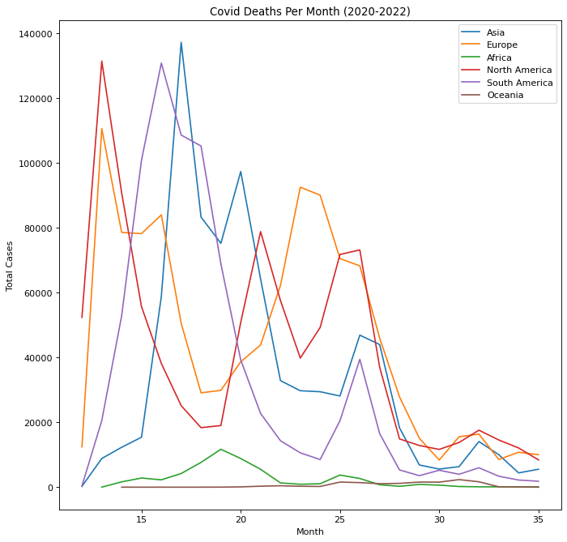

```python
# we sum up each continent's number of covid deaths using aggregate functions and separate them into different dataframs

# grouped by continent and month
overall_global_df = global_covid_df.groupby(['continent', 'monthByYear']).sum().reset_index()

# separate dataframes
asia = global_covid_df.groupby(['continent', 'monthByYear']).sum().reset_index().groupby(['continent']).get_group('Asia')
euro = global_covid_df.groupby(['continent',  'monthByYear']).sum().reset_index().groupby(['continent']).get_group('Europe')
africa = global_covid_df.groupby(['continent',  'monthByYear']).sum().reset_index().groupby(['continent']).get_group('Africa')
northAm = global_covid_df.groupby(['continent', 'monthByYear']).sum().reset_index().groupby(['continent']).get_group('North America')
southAm = global_covid_df.groupby(['continent','monthByYear']).sum().reset_index().groupby(['continent']).get_group('South America')
oc = global_covid_df.groupby(['continent',  'monthByYear']).sum().reset_index().groupby(['continent']).get_group('Oceania')

figure(figsize= (10, 10), dpi=80)

plt.title("Covid Deaths Per Month (2020-2022)")
plt.xlabel('Month')
plt.ylabel('Total Cases')
plt.plot(asia.monthByYear, asia.new_deaths, label = "Asia")
plt.plot(euro.monthByYear, euro.new_deaths, label = "Europe")
plt.plot(africa.monthByYear, africa.new_deaths, label = "Africa")
plt.plot(northAm.monthByYear, northAm.new_deaths, label = "North America")
plt.plot(southAm.monthByYear, southAm.new_deaths, label = "South America")
plt.plot(oc.monthByYear, oc.new_deaths, label = "Oceania")
plt.legend()
```

### Covid Vaccinations per Month

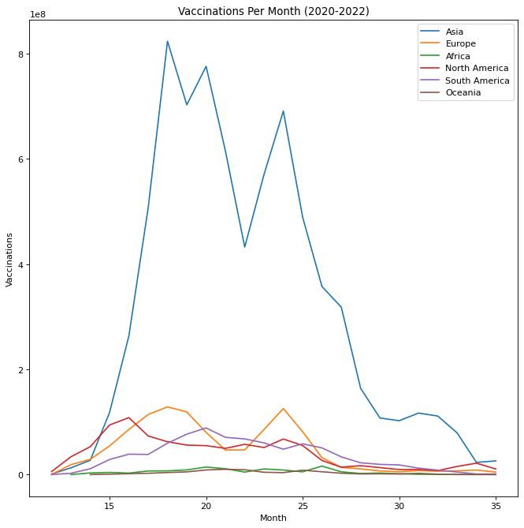

```python
figure(figsize= (10, 10), dpi=80)
plt.title("Vaccinations Per Month (2020-2022)")
plt.xlabel('Month')
plt.ylabel('Vaccinations')
plt.plot(asia.monthByYear, asia.new_vaccinations, label = "Asia")
plt.plot(euro.monthByYear, euro.new_vaccinations, label = "Europe")
plt.plot(africa.monthByYear, africa.new_vaccinations, label = "Africa")
plt.plot(northAm.monthByYear, northAm.new_vaccinations, label = "North America")
plt.plot(southAm.monthByYear, southAm.new_vaccinations, label = "South America")
plt.plot(oc.monthByYear, oc.new_vaccinations, label = "Oceania")
plt.legend()
```

### Correlation Between Vaccinations and Monthly Deaths

We now want to find some sort of correlation between covid vaccinations and covid deaths since the graphs above show each continents' vaccinations and deaths spiked or increased around the same time. I created 6 plots for each continent and measured the correlation individually. I tried to find a regression line for each continent to better visualize the correlation.

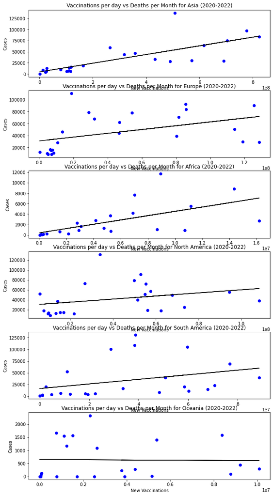

```python
# initializes the plots for each continent
fig, ax =plt.subplots(6, figsize=(10, 20))

# linear regression function to find the regression line for each plot more conveniently
def linearRegressionFunc(df):
    X = np.array(df['new_vaccinations']).reshape(-1, 1)
    y = np.array(df['new_deaths']).reshape(-1, 1)
    regr = LinearRegression()
    regr.fit(X, y)
    y_pred = regr.predict(X)
    #returns the X values, y values, predicted y values, coefficient, and intercept of regression line
    return (X, y, y_pred, regr.coef_, regr.intercept_)


asiaRef = linearRegressionFunc(asia)
ax[0].set_title("Vaccinations per day vs Deaths per Month for Asia (2020-2022)")
ax[0].set_xlabel('New Vaccinations')
ax[0].set_ylabel('Cases')
ax[0].scatter(asiaRef[0], asiaRef[1], color ='b')
ax[0].plot(asiaRef[0], asiaRef[2], color ='k')

euroRef = linearRegressionFunc(euro)
ax[1].set_title("Vaccinations per day vs Deaths per Month for Europe (2020-2022)")
ax[1].set_xlabel('New Vaccinations')
ax[1].set_ylabel('Cases')
ax[1].scatter(euroRef[0], euroRef[1], color ='b')
ax[1].plot(euroRef[0], euroRef[2], color ='k')

africaRef = linearRegressionFunc(africa)
ax[2].set_title("Vaccinations per day vs Deaths per Month for Africa (2020-2022)")
ax[2].set_xlabel('New Vaccinations')
ax[2].set_ylabel('Cases')
ax[2].scatter(africaRef[0], africaRef[1], color ='b')
ax[2].plot(africaRef[0], africaRef[2], color ='k')

northAmRef = linearRegressionFunc(northAm)
ax[3].set_title("Vaccinations per day vs Deaths per Month for North America (2020-2022)")
ax[3].set_xlabel('New Vaccinations')
ax[3].set_ylabel('Cases')
ax[3].scatter(northAmRef[0], northAmRef[1], color ='b')
ax[3].plot(northAmRef[0], northAmRef[2], color ='k')


southAmRef = linearRegressionFunc(southAm)
ax[4].set_title("Vaccinations per day vs Deaths per Month for South America (2020-2022)")
ax[4].set_xlabel('New Vaccinations')
ax[4].set_ylabel('Cases')
ax[4].scatter(southAmRef[0], southAmRef[1], color ='b')
ax[4].plot(southAmRef[0], southAmRef[2], color ='k')

ocmRef = linearRegressionFunc(oc)
ax[5].set_title("Vaccinations per day vs Deaths per Month for Oceania (2020-2022)")
ax[5].set_xlabel('New Vaccinations')
ax[5].set_ylabel('Cases')
ax[5].scatter(ocmRef[0], ocmRef[1], color ='b')
ax[5].plot(ocmRef[0], ocmRef[2], color ='k')
```

Other than Oceania, we realize there is a positive correlation between vaccinations per month and deaths per month. While we know this is due to the fact that vaccination rates increase when deaths increase to prevent further cases and casualties, to the viewer, this looks as though vaccinations cause deaths. Therefore, I decided to test the correlation of cumulative vaccinations and covid deaths between 2020 and 2022.

### Cumulative Vaccinations per Hundred People vs Deaths per Million

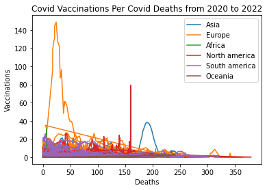

```python
plt.title("Covid Vaccinations Per Covid Deaths from 2020 to 2022")
plt.xlabel('Deaths')
plt.ylabel('Vaccinations')

# similar to before, we split each continents' data into their own dataframe for convenience
cumulAsia = global_covid_df[(global_covid_df.continent == "Asia")]
cumulEuro = global_covid_df[(global_covid_df.continent == "Europe")]
cumulAfrica = global_covid_df[(global_covid_df.continent == "Africa")]
cumulNorthAm = global_covid_df[(global_covid_df.continent == "North America")]
cumulSouthAm = global_covid_df[(global_covid_df.continent == "South America")]
cumulOc = global_covid_df[(global_covid_df.continent == "Oceania")]

# plot each correlation
plt.plot(cumulAsia.total_vaccinations_per_hundred, cumulAsia.new_deaths_smoothed_per_million, label = "Asia")
plt.plot(cumulEuro.total_vaccinations_per_hundred, cumulEuro.new_deaths_smoothed_per_million, label = "Europe")
plt.plot(cumulAfrica.total_vaccinations_per_hundred, cumulAfrica.new_deaths_smoothed_per_million, label = "Africa")
plt.plot(cumulNorthAm.total_vaccinations_per_hundred, cumulNorthAm.new_deaths_smoothed_per_million, label = "North america")
plt.plot(cumulSouthAm.total_vaccinations_per_hundred, cumulSouthAm.new_deaths_smoothed_per_million, label = "South america")
plt.plot(cumulOc.total_vaccinations_per_hundred, cumulOc.new_deaths_smoothed_per_million, label = "Oceania")

plt.legend()
```

The data is rather scattered but altogether, there is a negative correlation

### Checking Correlation One Last Time

```python
corr = overall_global_df['new_vaccinations'].corr(overall_global_df['new_deaths'])
print ("Correlation between ", 'global monthly new vaccinations', " and ", 'overall new deaths', " globally from 2020-2022 is: ", round(corr, 2))

corr = global_covid_df['total_vaccinations_per_hundred'].corr(global_covid_df['new_deaths_smoothed_per_million'])
print ("Correlation between ", 'cumulative vaccinations per hundred ppl', " and ", 'daily new deaths smoothed per million', " globally from 2020-2022 is: ", round(corr, 2))
```

```
Correlation between  global monthly new vaccinations  and  overall new deaths  globally from 2020-2022 is:  0.4
Correlation between  cumulative vaccinations per hundred ppl  and  daily new deaths smoothed per million  globally from 2020-2022 is:  -0.21
```

By checking correlation, we see the positive correlation between monthly covid vaccinations and monthly covid deaths. We can also tell for sure that there is a negative correlation between covid vaccinations and covid deaths in the second dataset. For the sake of logic then, it is best to go forward using the latter dataset.

### Hypothesis Testing

Now that we've visually established a correlation, let's try to prove it via a hypothesis test.

Null Hypothesis: There is no correlation between total_vaccinations_per_hundred, new_deaths_smoothed_per_million, and continent of covid deaths.

To test this, we first try to find the coefficients based off total_vaccinations_per_hundred, new_deaths_smoothed_per_million, and continent of covid deaths and fit a regression line using this data.

```python
temp = global_covid_df.dropna(subset=['total_vaccinations_per_hundred', 'new_deaths_smoothed_per_million', 'continent'])

# independent variable
# dummy variable to sort out categorical data (continent)
X = temp[['monthByYear', 'continent', 'total_vaccinations_per_hundred']]
X = pd.get_dummies(data=X)

# dependent variable
y = temp["new_deaths_smoothed_per_million"]

model = LinearRegression()
model.fit(X,y)

print("The Y intercept is: " + str(model.intercept_))

# calculated coefficients based off of linear regression line
coeff_parameter = pd.DataFrame(model.coef_,X.columns,columns=['Coefficient'])
predictions = model.predict(X)
coeff_parameter
```

```
The Y intercept is: 4.610584486050405
```

|  | Coefficient |
| --- | --- |
| monthByYear | -0.080449 |
| total_vaccinations_per_hundred | -0.007392 |
| continent_Africa | -1.580481 |
| continent_Asia | -0.786033 |
| continent_Europe | 1.277797 |
| continent_North America | 0.543891 |
| continent_Oceania | -1.016269 |
| continent_South America | 1.561096 |

We can go one step further by checking the p-values based on the model parameters.

```python
# printing out model parameters using the statsmodel library
X_train_Sm= sm.add_constant(X)
ls=sm.OLS(y,X).fit()
print(ls.summary())
```

```
                                   OLS Regression Results
===========================================================================================
Dep. Variable:     new_deaths_smoothed_per_million   R-squared:                       0.123
Model:                                         OLS   Adj. R-squared:                  0.123
Method:                              Least Squares   F-statistic:                     901.1
Date:                             Fri, 16 Dec 2022   Prob (F-statistic):               0.00
Time:                                     21:24:34   Log-Likelihood:            -1.2330e+05
No. Observations:                            44841   AIC:                         2.466e+05
Df Residuals:                                44833   BIC:                         2.467e+05
Df Model:                                        7
Covariance Type:                         nonrobust
==================================================================================================
                                     coef    std err          t      P>|t|      [0.025      0.975]
--------------------------------------------------------------------------------------------------
monthByYear                       -0.0804      0.005    -16.244      0.000      -0.090      -0.071
total_vaccinations_per_hundred    -0.0074      0.000    -19.662      0.000      -0.008      -0.007
continent_Africa                   3.0301      0.123     24.696      0.000       2.790       3.271
continent_Asia                     3.8246      0.091     42.149      0.000       3.647       4.002
continent_Europe                   5.8884      0.089     66.269      0.000       5.714       6.063
continent_North America            5.1545      0.101     51.105      0.000       4.957       5.352
continent_Oceania                  3.5943      0.140     25.733      0.000       3.321       3.868
continent_South America            6.1717      0.099     62.465      0.000       5.978       6.365
==============================================================================
Omnibus:                    71131.366   Durbin-Watson:                   0.058
Prob(Omnibus):                  0.000   Jarque-Bera (JB):        121109863.947
Skew:                           9.881   Prob(JB):                         0.00
Kurtosis:                     256.832   Cond. No.                     1.74e+03
==============================================================================

Notes:
[1] Standard Errors assume that the covariance matrix of the errors is correctly specified.
[2] The condition number is large, 1.74e+03. This might indicate that there are
strong multicollinearity or other numerical problems.
```

### Conclusion

We see that all p-values are less that 0.05 , which is the most commonly used significant value. This means that we can reject the null hypothesis, that the months between 2020-2022, continent, and total vaccinations per hundred have no correlation with new deaths smoothed per million, and that they in fact do have a relationship.

In the future, further research can be done using this data by analyzing factors that influence the positive correlation between some locations and covid deaths.